# Riz_Burkina_and_refs

Philippe Cubry

15/12/2020

```r
library(LEA)
library(data.table)
library(adegenet)
library(hierfstat)
library(pegas)
```

```r
library(ape)
library(ggimage)
library(ggtree)
library(tidyverse)
library(scales)
library(dplyr)
library(ggrepel)
library(cowplot)
library(ggnewscale)

data <- read.lfmm("burkina_ref_snpseek.lfmm")
inds <- fread("burkina_ref_snpseek.ind",header = FALSE)
snps <- fread("burkina_refsnpseek.snp",header=FALSE)
data[data==9] <- NA
row.names(data) <- snps$V1
colnames(data) <- inds$V1
bk_inds <- read.table("bk_inds.csv")
```

# Data filtering

## Missingness

As we have a very large dataset for the 3k genomes, we chose to first compute missingness only on the Burkinabese dataset.

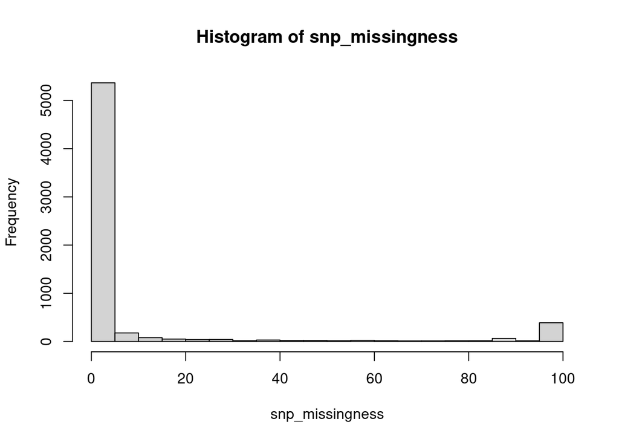

```r
snp_missingness <- apply(data[,1:nrow(bk_inds)],1,FUN = function(x){length(which(is.na(x)))/length(x)*100}) # Compute proportion of missing data per SNP
hist(snp_missingness,breaks = 20) # Draw histogram of missingness
```

We chose a cutoff of 15% for keeping SNPs.

```r
data <- data[snp_missingness<=15,]
```

This resulted in keeping 5623 SNPs from the 6417 initial dataset.

We computed again the missingness on the whole dataset to validate the quality of retained SNPs.

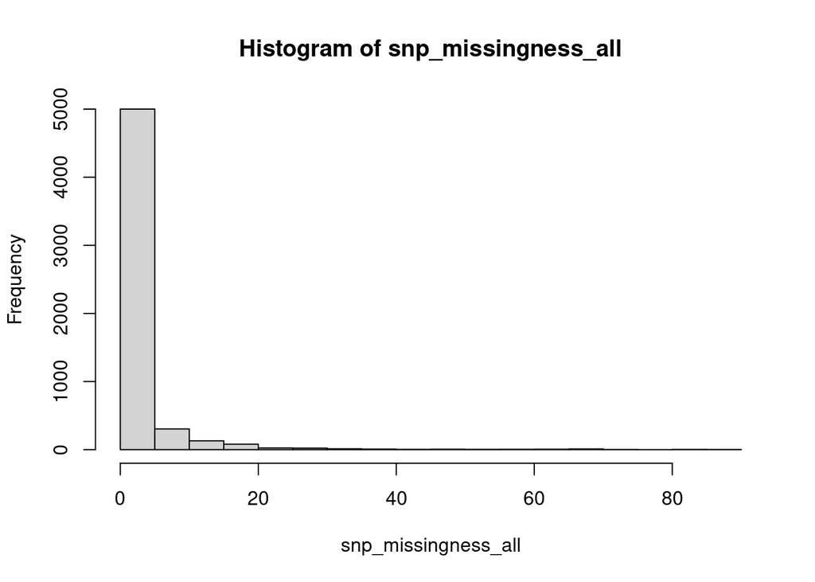

```r
snp_missingness_all <- apply(data[,],1,FUN = function(x){length(which(is.na(x)))/length(x)*100}) # Compute proportion of missing data per SNP
hist(snp_missingness_all,breaks = 20) # Draw histogram of missingness
```

As we still have some SNPs with large portion of missing data, we apply a new filter on the whole dataset. We chose a more stringent cutoff of 10% for keeping SNPs.

```r
data <- data[snp_missingness_all<=10,]
```

This resulted in finally keeping 5305 SNPs from the 6417 initial dataset.

## Heterozygosity

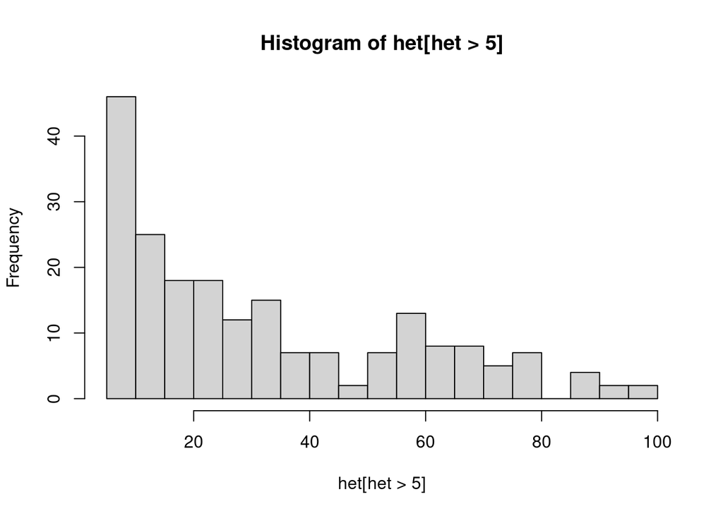

```r
het <- apply(data,1,function(x){x=na.omit(x);sum(x==1)/length(x)*100})
hist(het[het>5],breaks = 20)
```

As high heterozygosity might be due to genotyping bias or duplicated locus, we filtered out SNPs with more than 45% of heterozygosity.

```r
data <- data[het <= 45,]
```

This resulted in a dataset with 5247 SNPs.

## Minimum Allele Frequency

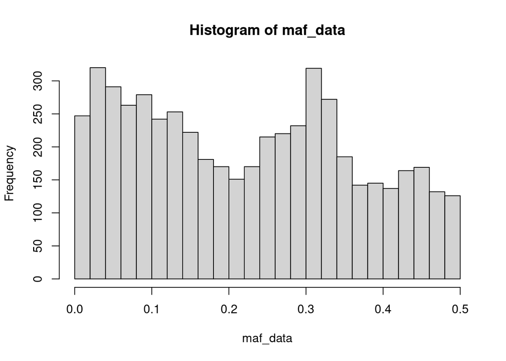

```r
maf_diplo <- function(x){ x <- as.numeric(na.omit(x));(min(sum(x),2*length(x)-sum(x)))/(2*length(x))}
maf_data <- apply(data,1,maf_diplo)
hist(maf_data,breaks = 25)
```

This distribution of allele frequencies appears to be unusual but it might be related to the choice of SNPs for the chip. Therefore for a first analysis we did not apply any filter on this statistic.

We thus obtained a dataset with 5247 SNPs after filtering.

## Exporting data

```r
tmp <- t(apply(data,2,as.numeric))
write.lfmm(tmp,"burkina_ref_filtered_publi.lfmm")
```

```
## [1] "burkina_ref_filtered_publi.lfmm"
```

```r
inds <- colnames(data) ; write.table(inds,"burkina_ref_filtered_publi.ind",row.names = F,col.names = F,quote = F)
snps <- row.names(data) ; write.table(snps,"burkina_ref_filtered_publi.snp",row.names = F,col.names = F,quote = F)
rm(tmp,maf_data,snp_missingness,snp_missingness_all,het)
```

# Analysis

## PCA

We can first easily make a Principal Component Analysis based on the filtered dataset.

```r
pca_both <- pca("burkina_ref_filtered_publi.lfmm")
```

```
## [1] "******************************"
## [1] " Principal Component Analysis "
## [1] "******************************"
## summary of the options:
##
##         -n (number of individuals)          3100
##         -L (number of loci)                 5247
##         -K (number of principal components) 3100
##         -x (genotype file)                  /home/cubry/Documents/Charlotte/pour_publi/burkina_ref_filtered_publi.lfmm
##         -a (eigenvalue file)                /home/cubry/Documents/Charlotte/pour_publi/burkina_ref_filtered_publi.pca/burkina_ref_filtered_publi.eigenvalues
##         -e (eigenvector file)               /home/cubry/Documents/Charlotte/pour_publi/burkina_ref_filtered_publi.pca/burkina_ref_filtered_publi.eigenvectors
##         -d (standard deviation file)        /home/cubry/Documents/Charlotte/pour_publi/burkina_ref_filtered_publi.pca/burkina_ref_filtered_publi.sdev
##         -p (projection file)                /home/cubry/Documents/Charlotte/pour_publi/burkina_ref_filtered_publi.pca/burkina_ref_filtered_publi.projections
##         -c data centered
```

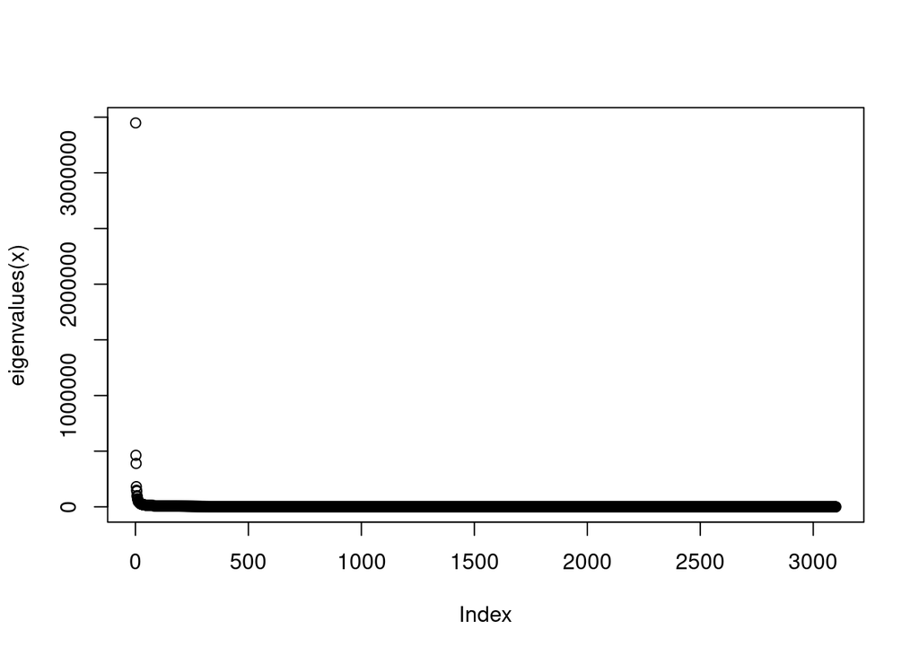

```r
plot(pca_both)
```

We see here that the three first components explain a large portion of the variation, contributing respectively 0.3640015, 0.0488752 and 0.0410949 to the explanation of variance. We can now plot the resulting PCA, on axes 1-2 and 2-3.

```r
burk_passport_tmp <- fread("Sample_List_12072021.csv")
burk_passport <- merge(inds[1:nrow(bk_inds)],burk_passport_tmp,by.x=1,by.y="Name",sort = F)

ref_passport_tmp <- fread("varieties-3442742964161006397.csv")
ref_passport <- merge(inds[(nrow(bk_inds)+1):ncol(data)],ref_passport_tmp,by.x=1,by.y="ID",sort = F,all.x=TRUE)

pca_passport <- rbind(burk_passport[,c("x","Type1")],cbind("x"=ref_passport[,1],"Type1"=ref_passport[,6]))
pca_passport_2 <- rbind(burk_passport[,c("x","Type1")],cbind("x"=ref_passport[,1],"Type1"=ref_passport[,5]))

library(ggplot2)
```

We can superimpose the Burkinabese samples over the whole PCA.

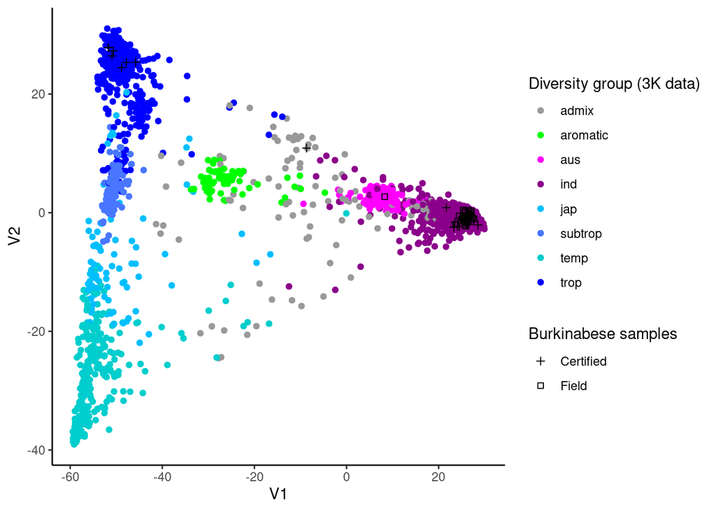

```r
myCol <- c("grey60","green1","magenta","magenta4","deepskyblue","royalblue1","cyan3","blue1")
ggplot(data=as.data.frame(pca_both$projections[(nrow(bk_inds)+1):nrow(pca_both$projections),]))+
  geom_point(aes(V1,V2,col=as.factor(pca_passport$Type1[(nrow(bk_inds)+1):nrow(pca_both$projections)])))+
  scale_color_manual(values=myCol) +
  geom_point(data=as.data.frame(pca_both$projections[1:nrow(bk_inds),]),aes(V1,V2,shape= burk_passport$Type1),col="black")+
  scale_shape_manual(values=c(3,0))+
  theme_classic()+
  guides(
    colour = guide_legend("Diversity group (3K data)"),
    shape = guide_legend("Burkinabese samples")
 )
```

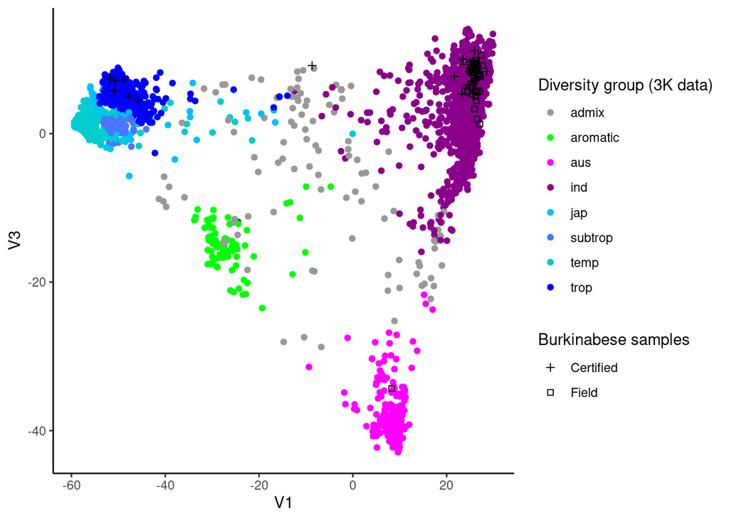

```r
ggplot(data=as.data.frame(pca_both$projections[(nrow(bk_inds)+1):nrow(pca_both$projections),]))+
  geom_point(aes(V1,V3,col=as.factor(pca_passport$Type1[(nrow(bk_inds)+1):nrow(pca_both$projections)])))+
  scale_color_manual(values=myCol) +
  geom_point(data=as.data.frame(pca_both$projections[1:nrow(bk_inds),]),aes(V1,V3,shape= burk_passport$Type1),col="black")+
  scale_shape_manual(values=c(3,0))+
  theme_classic()+
  guides(
    colour = guide_legend("Diversity group (3K data)"),
    shape = guide_legend("Burkinabese samples")
 )
```

Based on this PCA, we can observe that the references genotypes seems to correspond to the genetic groups from the 3k genomes, mainly from the indica and tropical japonica, with one (FKR04) being classified with the admixed. All field genotypes but one fall well within the indica diversity group. One field genotype (TG02) appears to be related to the aus genetic group.

```r
rm(pca_both)
```

## Conversion to genind (adegenet)

```r
data[data==0] <- "0/0"
data[data==1] <- "0/1"
data[data==2] <- "1/1"
ade <- df2genind(X=t(data),sep="/",ncode=1,ind.names=inds,loc.names=snps,NA.char=NA,ploidy=2,type="c",pop=pca_passport$Type1)
```

As the grouping appears pretty good regarding the previously made PCA, we can use the DAPC functionnality of adegenet based on defined groups to identify discriminant functions and then apply them to the Field and MP groups to assign individuals to representative diversity clusters. We first run the DAPC on the identified diversity groups and assess the performance of the clustering.

```r
dapc_rice <- dapc(ade[pop(ade)!="Field"&pop(ade)!="admix"&pop(ade)!="Certified"],
                 pop(ade[pop(ade)!="Field"&pop(ade)!="admix"&pop(ade)!="Certified"]),
                 n.pca=250,
                 n.da=6)

myCol <- c("darkblue","purple","green","orange","red","blue","gray15")

scatter(dapc_rice,1,2, bg="white", pch=20, cell=0,
cstar=0, col=myCol,  cex=3, clab=0,solid=.4,
scree.da=FALSE,
scree.pca=TRUE, posi.pca="topleft",
leg=TRUE,
txt.leg=levels(pop(ade[pop(ade)!="Field"&pop(ade)!="admix"&pop(ade)!="Certified"])))
```

[figure not shown]

```r
scatter(dapc_rice,1,3, bg="white", pch=20, cell=0,
cstar=0, col=myCol,  cex=3, clab=0,solid=.4,
scree.da=FALSE,
scree.pca=TRUE, posi.pca="bottomright",
leg=TRUE,
txt.leg=levels(pop(ade[pop(ade)!="Field"&pop(ade)!="admix"&pop(ade)!="Certified"])))
```

[figure not shown]

```r
summary(dapc_rice)
```

```
## $n.dim
## [1] 6
##
## $n.pop
## [1] 7
##
## $assign.prop
## [1] 0.9907534
##
## $assign.per.pop
##      temp       jap       ind      trop       aus   subtrop  aromatic
## 0.9407666 0.9036145 0.9994410 0.9973118 1.0000000 1.0000000 1.0000000
##
## $prior.grp.size
##
##     temp      jap      ind     trop      aus  subtrop aromatic
##      287       83     1789      372      201      112       76
##
## $post.grp.size
##
##     temp      jap      ind     trop      aus  subtrop aromatic
##      271       92     1789      374      201      116       77
```

We obtain a pretty good predictor for group membership (above 90% of correct posterior assignation compared to prior information), especially for indica, aus and aromatic groups. We can thus use this trained discriminant analysis to attribute Burkinabese genotypes to genetic clusters with correct accuracy.

```r
pred_admix <- predict.dapc(dapc_rice,ade[pop(ade)=="admix"])
pred_admix$assign
```

```
##   [1] ind      temp     jap      ind      temp     ind      ind      ind
##   [9] temp     ind      aromatic ind      aus      aromatic ind      ind
##  [17] ind      temp     temp     ind      ind      ind      ind      temp
##  [25] ind      trop     jap      jap      ind      jap      ind      aus
##  [33] ind      ind      jap      ind      subtrop  trop     ind      trop
##  [41] jap      ind      aromatic ind      ind      ind      ind      aus
##  [49] ind      ind      jap      jap      ind      ind      aromatic ind
##  [57] ind      ind      ind      ind      ind      ind      aromatic aus
##  [65] ind      jap      aus      aus      trop     ind      ind      aromatic
##  [73] ind      aromatic aromatic ind      aus      ind      ind      aromatic
##  [81] aus      ind      ind      aromatic ind      aromatic ind      ind
##  [89] ind      aromatic ind      aus      aus      ind      ind      jap
##  [97] ind      ind      ind      ind      trop     trop     ind
## Levels: temp jap ind trop aus subtrop aromatic
```

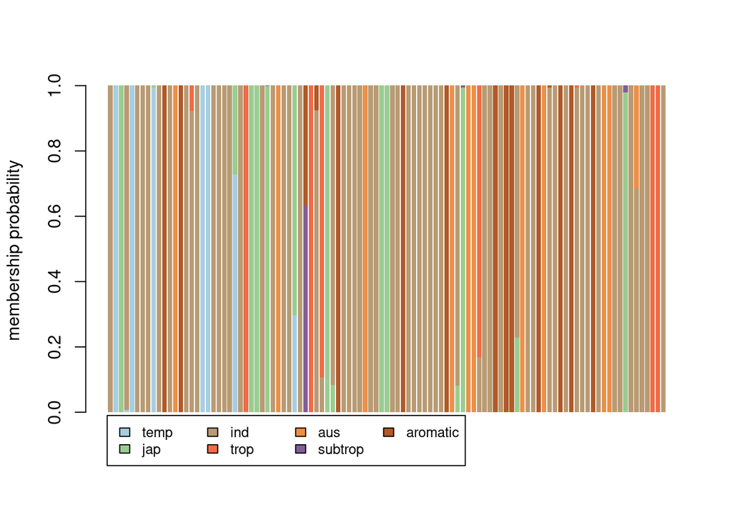

```r
compoplot(pred_admix$posterior)
```

```r
pred_Ref <- predict.dapc(dapc_rice,ade[pop(ade)=="Certified"])
pred_Ref$assign
```

```
##  [1] ind  trop ind  ind  ind  trop ind  ind  trop ind  ind  ind  trop ind  ind
## [16] trop ind  ind  ind  ind  ind  ind  trop trop ind  ind  ind
## Levels: temp jap ind trop aus subtrop aromatic
```

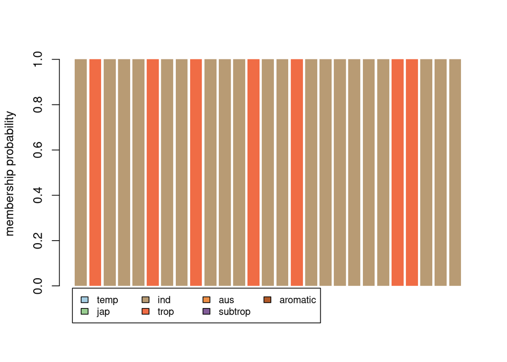

```r
compoplot(pred_Ref$posterior)
```

```r
pred_Field <- predict.dapc(dapc_rice,ade[pop(ade)=="Field"])
pred_Field$assign
```

```
##  [1] ind ind ind ind ind ind ind ind ind ind ind ind ind ind ind ind ind ind ind
## [20] ind ind ind ind ind ind ind ind ind ind ind ind ind ind ind ind ind ind ind
## [39] ind ind ind ind ind ind ind ind aus ind ind ind
## Levels: temp jap ind trop aus subtrop aromatic
```

```r
rownames(pred_Field$posterior)[pred_Field$assign=="aus"]
```

```
## [1] "Field_2018_TG02"
```

Reference genotypes are either assigned to indica or japonica tropical clusters. All but one field genotypes was assigned to the indica group. Only Field_2018_TG02 is assigned to the aus genetic cluster.

We can go a little further by investigating more in details the indica group. The 3k genomes consider sub-groups within the indica that we can use.

```r
ade_b <- df2genind(X=t(data),sep="/",ncode=1,ind.names=inds,loc.names=snps,NA.char=NA,ploidy=2,type="c",pop=pca_passport_2$Type1)

dapc_ind <- dapc(ade_b[pop(ade_b)=="indx"|pop(ade_b)=="ind1A"|pop(ade_b)=="ind1B"|pop(ade_b)=="ind2"|pop(ade_b)=="ind3"],
                 pop(ade_b[pop(ade_b)=="indx"|pop(ade_b)=="ind1A"|pop(ade_b)=="ind1B"|pop(ade_b)=="ind2"|pop(ade_b)=="ind3"]),
                 n.pca=250,
                 n.da=4)


scatter(dapc_ind,1,2, bg="white", pch=20, cell=0,
cstar=0, col=myCol,  cex=3, clab=0,solid=.6,
scree.da=FALSE,
scree.pca=TRUE, posi.pca="topleft",
leg=TRUE,
txt.leg=levels(pop(ade_b[pop(ade_b)=="indx"|pop(ade_b)=="ind1A"|pop(ade_b)=="ind1B"|pop(ade_b)=="ind2"|pop(ade_b)=="ind3"])))
```

[figure not shown]

```r
scatter(dapc_ind,1,3, bg="white", pch=20, cell=0,
cstar=0, col=myCol,  cex=3, clab=0,solid=.4,
scree.da=FALSE,
scree.pca=TRUE, posi.pca="bottomright",
leg=TRUE,
txt.leg=levels(pop(ade_b[pop(ade_b)=="indx"|pop(ade_b)=="ind1A"|pop(ade_b)=="ind1B"|pop(ade_b)=="ind2"|pop(ade_b)=="ind3"])))
```

[figure not shown]

```r
summary(dapc_ind)
```

```
## $n.dim
## [1] 4
##
## $n.pop
## [1] 5
##
## $assign.prop
## [1] 0.9625489
##
## $assign.per.pop
##      indx     ind1A      ind2      ind3     ind1B
## 0.9365854 0.9712919 0.9964912 0.9852632 0.9317073
##
## $prior.grp.size
##
##  indx ind1A  ind2  ind3 ind1B
##   615   209   285   475   205
##
## $post.grp.size
##
##  indx ind1A  ind2  ind3 ind1B
##   604   206   296   475   208
```

As the groups are more genetically close than previously, the accuracy of the clustering appears weaker, still we can assign the Field individuals to the ind clusters after removing the TG02 which was classified with the aus group.

```r
pred_Field <- predict.dapc(dapc_ind,ade_b[pop(ade_b)=="Field"&indNames(ade_b)!="Field_2018_TG02"])
pred_Field$assign
```

```
##  [1] ind1B indx  indx  ind1B ind1B ind1B ind1B ind1B ind1B ind1B indx  indx
## [13] ind1B indx  ind1B indx  indx  indx  ind1B indx  ind1B indx  ind1B indx
## [25] indx  ind1B ind1B indx  ind1B ind1B ind1B indx  indx  ind1B ind1B ind1B
## [37] ind1B indx  ind1B indx  indx  ind1B ind1B ind3  indx  ind3  ind3  indx
## [49] indx
## Levels: indx ind1A ind2 ind3 ind1B
```

The Field genotypes belong either to clusters indxn ind1B or ind3. All in all it indicates that some of the indica diversity is present in Burkina but that there is still some untaped genetic diversity in this diversity group, not to mention the other ones. We will now do a little cleaning of the environment before going more in depth with the intra-Burkina analysis.

```r
rm(ade_b,treeFst,pred_admix,pred_Field,pred_Ref)
```

We can now focus on the cultivated Burkinabese samples. First we extract those genotypes from the dataset, then we import the passport data in the strata slot of the field genind object.

```r
field <- seppop(ade)$Field
burk_all <- repool(seppop(ade)$Certified,seppop(ade)$Field)
strata(field) <- merge(x = indNames(field),y = burk_passport_tmp,by.x=1,by.y="Name",sort=FALSE)
colnames(strata(field))[1] <- "id"
strata(burk_all) <- merge(x = indNames(burk_all),y = burk_passport_tmp,by.x=1,by.y="Name",sort=FALSE)
colnames(strata(burk_all))[1] <- "id"
```

We can now use the passport data to set populations for the diversity/Fst analysis. First we calculate genetic distances btwn Burkinabese accessions (including Ref and Field collected samples) and draw a NJ tree.

```r
library(ape)
setPop(burk_all) <- ~Rice_system
burkina_dist <- dist.gene(burk_all@tab,pairwise.deletion = F)
burkina_tree <- njs(burkina_dist,fs = 10)
burkina_tree$tip.label <- merge(burkina_tree$tip.label,burk_passport_tmp,by.x=1,by.y="Name",sort=FALSE)$Final_Name
burk_color <- c(rep("gray50",length(which(strata(burk_all)$Type1=="Certified"))),c("cyan2","coral2")[pop(burk_all)][length(which(strata(burk_all)$Type1=="Certified"))+1:length(which(strata(burk_all)$Type1!="Certified"))])
pdf(file = "Burk_tree_phylogram.pdf")
plot(burkina_tree,type = "p",cex=0.6,tip.color=burk_color,lab4ut="axial")
dev.off()
```

```r
pdf(file = "Burk_tree_unrooted.pdf")
plot(burkina_tree,type = "u",cex=0.6,tip.color=burk_color,lab4ut="axial")
dev.off()
```

```r
write.tree("Burk_tree.newick",phy = burkina_tree)
fwrite(as.matrix(burkina_dist),"Burk_dist.csv")
```

```
## x being coerced from class: matrix to data.table
```

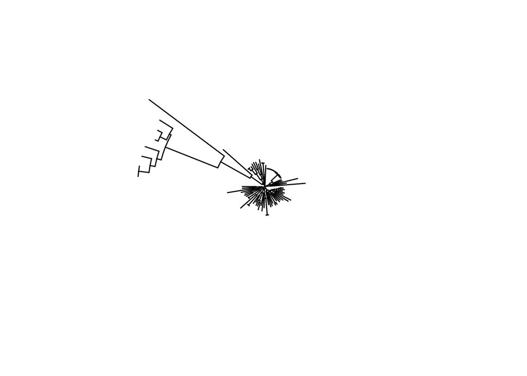

```r
p<-ggtree(burkina_tree, layout="fan")
p
```

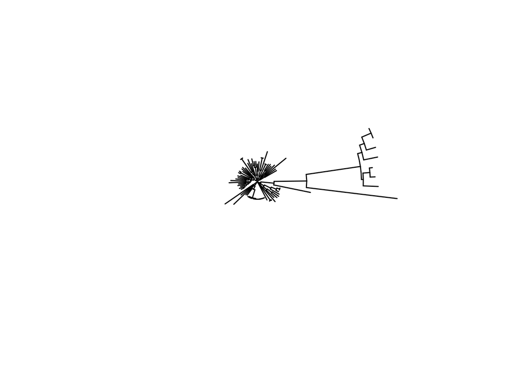

```r
# rotation de l'ensemble de l'arbre
p_rot<-rotate_tree(p, 210)
p_rot
```

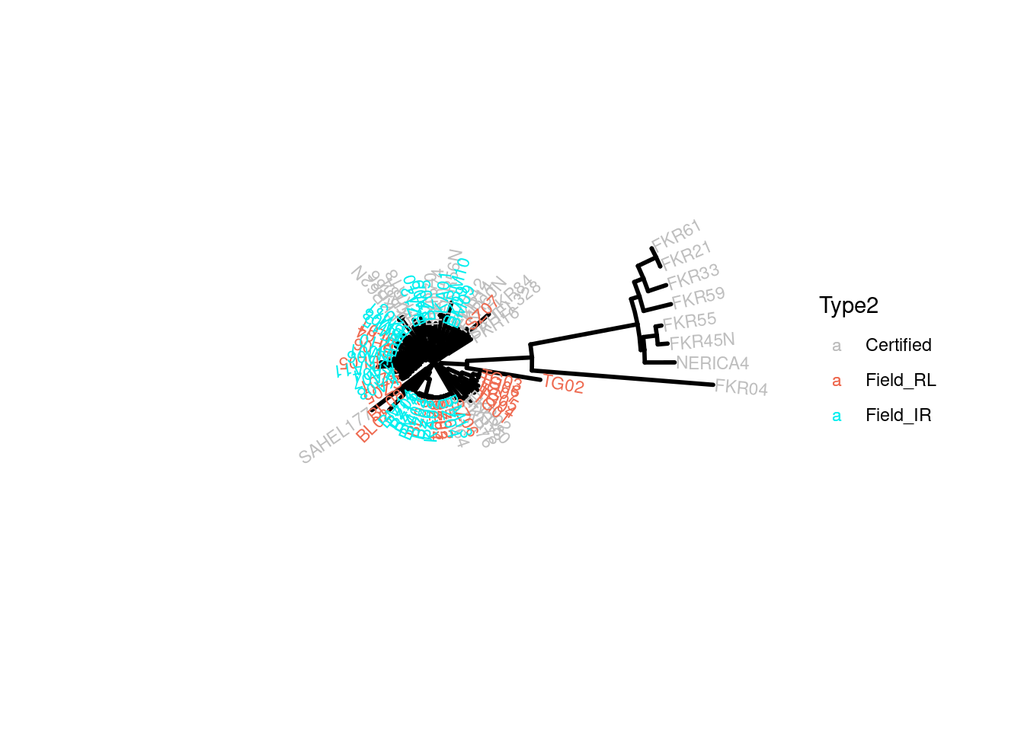

```r
metadata<-(strata(burk_all)[,-c(1:3)])

# dessiner l'arbre AVEC metadonnées   #circular
p <- ggtree(burkina_tree, layout="circular", size=1, linetype=1) %<+% metadata
p1<-rotate_tree(p, 210)+  geom_tiplab(aes(color = Type2), size=3)+
    scale_color_manual(values=c( "grey", "coral2", "cyan2"))
p1
```

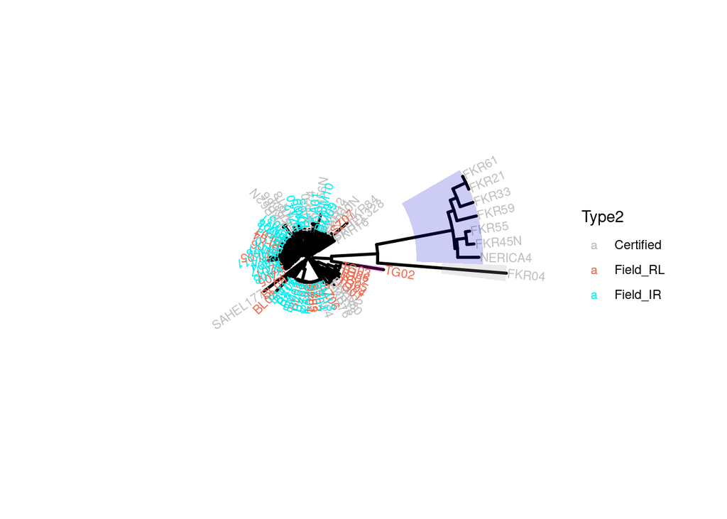

```r
# colorer les clades. alpha règle le niveau de transparence.
p_col<-p1 +
  geom_hilight(node=147, fill="#0000CC", alpha=0.2, extend=10)+
  geom_hilight(node=74, fill="#FF00FF", alpha=0.2)+
  geom_hilight(node=8, fill="#999999", alpha=0.2)
p_col
```

```r
ggsave("tree_test_v.pdf", width = 50, height = 50, units = "cm", limitsize = FALSE)
```

```r
setPop(field) <- ~Site2
hier(field) <- ~Zone/Site2
```

```r
field_data <- tab(field,freqq=TRUE,NA.method="mean")
field_pca <- dudi.pca(field_data,nf=4,scannf = FALSE)

p1 <- ggplot(data=field_pca$li)+
  geom_point(aes(Axis1,Axis2,col=as.factor(strata(field)$Rice_system),shape=strata(field)$Zone),size=3,alpha=0.6)+
  scale_color_manual(name = "Rice system", breaks=c("IR","RL"), values = c("cyan2", "coral2")) +
  scale_shape_manual(name = "Zone", breaks=c("Bama","Banzon","Karfiguela"), values = c(19,17,15)) +
  theme_classic()

p2 <- ggplot(data=field_pca$li,aes(Axis1,Axis2,col=as.factor(strata(field)$Variete_cultivee_cat)))+
  geom_point(size=2)+
  scale_color_manual(name = "Cultivated variety", breaks=c("FKR64","FKR62N","Hom_aut","Pay"), values = c("#CC33CC", "#9933FF","#4A1486","#00CC66"))+
geom_text_repel(aes(Axis1,Axis2,label=strata(field)$Final_Name),max.overlaps = 100,
    segment.linetype = 2,size=3) + guides(color = guide_legend(override.aes = aes(label = "")))+

  theme_classic()
pdf(file = "Burk_field_test1.pdf",width = 15,height = 6)
plot_grid(p1, p2, labels = c('a', 'b'), label_size = 12)
dev.off()
```

```r
pdf(file = "Burk_field_test2.pdf",width = 16,height = 12)
ggplot(data=field_pca$li,aes(Axis1,Axis2,col=as.factor(strata(field)$Rice_system),shape=strata(field)$Zone))+
  geom_point(size=2.5)+
  scale_color_manual(name = "Rice system", breaks=c("IR","RL"), values = c("cyan2", "coral2")) +
  scale_shape_manual(name = "Zone", breaks=c("Bama","Banzon","Karfiguela"), values = c(19,17,15))+
  new_scale_color()+scale_color_manual(name = "Named variety", breaks=c("FKR64","FKR62N","Hom_aut","Pay"), values = c("#CC33CC", "#9933FF","#4A1486","#00CC66"))+
  geom_text_repel(aes(Axis1,Axis2,label=strata(field)$Final_Name,col=as.factor(strata(field)$Variete_cultivee_cat)),box.padding = .5,size=4,max.overlaps = 30,
    segment.linetype = 2,segment.size=0.5) +
  theme_classic()
dev.off()
```

```r
pdf(file = "Burk_field_test3.pdf",width = 12,height = 8)
ggplot(data=field_pca$li[-which(strata(field)$Final_Name=="TG02"),],aes(Axis1,Axis2,col=strata(field)$Rice_system[-which(strata(field)$Final_Name=="TG02")],shape=strata(field)$Zone[-which(strata(field)$Final_Name=="TG02")]))+
  geom_point(size=2.5,alpha=0.5)+
  scale_color_manual(name = "Rice system", breaks=c("IR","RL"), values = c("cyan2", "coral2")) +
  scale_shape_manual(name = "Zone", breaks=c("Bama","Banzon","Karfiguela"), values = c(19,17,15))+
  new_scale_color()+scale_color_manual(name = "Named variety", breaks=c("FKR64","FKR62N","Hom_aut","Pay"), values = c("#CC33CC", "#9933FF","#4A1486","#00CC66"))+
  geom_text_repel(aes(Axis1,Axis2,label=strata(field)$Final_Name[-which(strata(field)$Final_Name=="TG02")],col=strata(field)$Variete_cultivee_cat[-which(strata(field)$Final_Name=="TG02")]),box.padding = .3,size=4,max.overlaps = 50,
    segment.linetype = 2,segment.size=0.5,point.padding=0.5) +
  theme_classic()
dev.off()
```

We can also compute some summary statistics at different hierarchy levels as well as estimate the pairwise Fst between populations defined with regard to the hierarchic level considered.

```r
setPop(field) <- ~Type1
field_Stats <- basic.stats(field)
apply(field_Stats$Hs,2,mean)
```

```
##         1    dumpop
## 0.1372184        NA
```

```r
field_fst <- pairwise.WCfst(dat=genind2hierfstat(field))
field_fstBootstp <- boot.ppfst(field)

setPop(field) <- ~Zone
zone_Stats <- basic.stats(field)
apply(zone_Stats$Hs,2,mean)
```

```
##       Bama     Banzon Karfiguela
##  0.1253405  0.1128600  0.1552491
```

```r
zone_fst <- pairwise.WCfst(dat=genind2hierfstat(field))
zone_fstBootstp <- boot.ppfst(field)

setPop(field) <- ~Rice_system
riceSyst_Stats <- basic.stats(field)
apply(riceSyst_Stats$Hs,2,mean)
```

```
##        RL        IR
## 0.1489856 0.1252725
```

```r
riceSyst_fst <- pairwise.WCfst(dat=genind2hierfstat(field))
riceSyst_fstBootstp <- boot.ppfst(field)

setPop(field) <- ~Site2
site2_Stats <- basic.stats(field)
apply(site2_Stats$Hs,2,mean)
```

```
##       Bama_RL       Bama_IR     Banzon_IR Karfiguela_IR     Banzon_RL
##     0.1171255     0.1311683     0.1080956     0.1297799     0.1243302
## Karfiguela_RL
##     0.1325945
```

```r
site2_fst <- pairwise.WCfst(dat=genind2hierfstat(field))
site2_fstBootstp <- boot.ppfst(field)
```

For comparison purpose, we can calculate the summary statistics on the whole 3K set.

```r
rice3k_Stats <- basic.stats(ade)
apply(rice3k_Stats$Hs,2,mean)
```

```
## Certified     Field      temp       jap       ind      trop     admix       aus
## 0.2815640 0.1372184 0.1321085 0.2113924 0.1682764 0.1847945 0.3139574 0.1319377
##   subtrop  aromatic
## 0.1129194 0.1564417
```